# Simulation

Ying Jin

2024-10-07

# Simulation: dynamic prediction

## Simulation set-up

This file documents the simulation scheme of multi-level functional data.

$$Y_{ij}(t) \sim
Bernoulli(g(\eta_{ij}(t)))$$

$$\eta_{ij}(t)=b_0(t)+\sum_{l=1}^4\xi_{il}\phi_l(t)+\sum_{m=1}^4\zeta_{ijm}\psi_m(t)$$

- Level 1:

$$\phi_l(t) = \{\sqrt{2}sin(2\pi t),
\sqrt2 cos(2\pi t), \sqrt2 sin (4\pi t), \sqrt2 cos(4\pi
t)\}$$

$$\xi_{il} \sim N(0, \lambda_l),
\hspace{0.5cm} \lambda_l = 0.5^{l-1}, l=1,2, 3, 4$$

## Results

### Figure

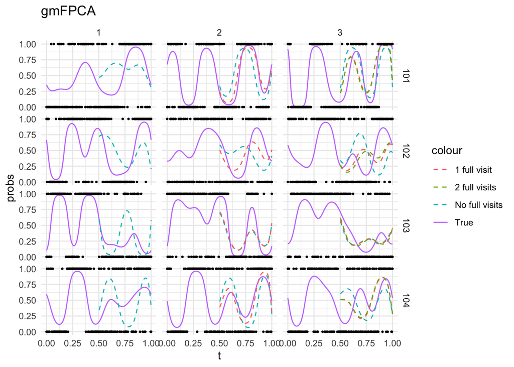

```r
pred_list_allM[[1]] %>%
  filter(id %in% 101:104) %>%
  mutate(eta_pred_J1 = ifelse(t<=0.5, NA, eta_pred_J1),
         eta_pred_J2 = ifelse(visit==1|(visit %in% 2:3 & t<=0.5), NA, eta_pred_J2),
         eta_pred_J3 = ifelse(visit %in% 1:2|(visit==3&t<=0.5), NA, eta_pred_J3)) %>%
  mutate_at(vars(starts_with("eta_pred")), function(x)(exp(x)/(1+exp(x)))) %>%
  ggplot()+
  geom_line(aes(x=t, y=probs, col="True"))+
  geom_line(aes(x=t, y=eta_pred_J1, col = "No full visits"), linetype="dashed",
            na.rm = T)+
  geom_line(aes(x=t, y=eta_pred_J2, col = "1 full visit"), linetype="dashed",
            na.rm = T)+
  geom_line(aes(x=t, y=eta_pred_J3, col = "2 full visits"), linetype="dashed",
            na.rm = T)+
  geom_point(aes(x=t, y=Y), size = 0.5)+
  facet_grid(row = vars(id), col=vars(visit))+
  labs(title = "gmFPCA")
```

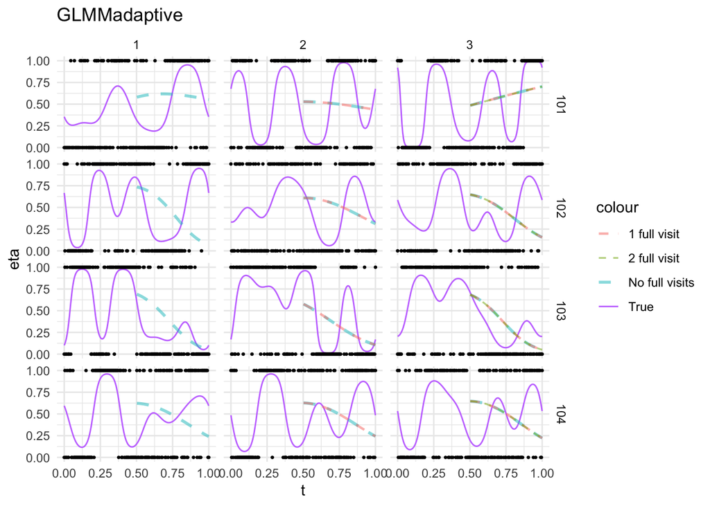

```r
pred_list_allM_ref[[1]] %>%
  filter(id %in% 101:104) %>%
  mutate(eta_pred_J1 = ifelse(t<=0.5, NA, eta_pred_J1),
         eta_pred_J2 = ifelse(visit==1|(visit %in% 2:3 & t<=0.5), NA, eta_pred_J2),
         eta_pred_J3 = ifelse(visit %in% 1:2|(visit==3&t<=0.5), NA, eta_pred_J3)) %>%
  mutate_at(vars(starts_with("eta")), function(x)(exp(x)/(1+exp(x)))) %>%
  ggplot()+
  geom_line(aes(x=t, y=eta, col="True"))+
  geom_line(aes(x=t, y=eta_pred_J1, col = "No full visits"), linetype="dashed",
            na.rm = T, alpha = 0.5, linewidth = 1)+
  geom_line(aes(x=t, y=eta_pred_J2, col = "1 full visit"), linetype="dashed",
            na.rm = T, alpha = 0.5, linewidth = 0.8)+
  geom_line(aes(x=t, y=eta_pred_J3, col = "2 full visit"), linetype="dashed",
            na.rm = T, alpha = 0.5, linewidth = 0.6)+
  geom_point(aes(x=t, y=Y), size = 0.5)+
  facet_grid(row = vars(id), col=vars(visit))+
  labs(title = "GLMMadaptive")
```

### Computation time

```r
# print("Computation time:")
data.frame("gmFPCA" = c(mean(fit_time_vec),
                        mean(pred_time_vec)),
           "GLMMadaptive" = c(mean(fit_time_vec_ref),
                              mean(pred_time_vec_ref))) %>%
  mutate("Time (mins)" = c("Fit", "Prediction"), .before=1) %>%
  kable(digits = 2) %>%
  kable_styling(full_width = F)
```

| Time (mins) | gmFPCA | GLMMadaptive |
| --- | --- | --- |
| Fit | 0.39 | 2.40 |
| Prediction | 5.82 | 0.02 |

### Integerated squared error

- Over the entire prediction window

```r
ise_gmfpca <- bind_rows(pred_list_allM, .id = "iter") %>%
  mutate(window = cut(t, breaks = c(0, 0.5, 1), include.lowest = T)) %>%
  mutate(error_J1 = (eta_pred_J1-eta)^2,
         error_J2 = (eta_pred_J2-eta)^2,
         error_J3 = (eta_pred_J3-eta)^2) %>%
  group_by(iter, visit, window, id) %>%
  summarise_at(vars(starts_with("error_")), sum) %>%
  group_by(iter, visit, window) %>%
  summarise_at(vars(starts_with("error_")), mean) %>%
  group_by(visit, window) %>%
  summarise_at(vars(starts_with("error_")), mean)

ise_gmfpca <- ise_gmfpca %>% filter(window == "(0.5,1]")
ise_gmfpca$error_J2[1] <- NA
ise_gmfpca$error_J3[1:2] <- NA
colnames(ise_gmfpca) <- c("Visit", "Time",
                          "All half visits", "Full visit 1, half visit 2 and 3",
                          "Full visit 1 and 2, half visit 3")
```

```r
ise_glmmad <- bind_rows(pred_list_allM_ref, .id = "iter") %>%
  mutate(window = cut(t, breaks = c(0, 0.5, 1), include.lowest = T)) %>%
  mutate(error_J1 = (eta_pred_J1-eta)^2,
         error_J2 = (eta_pred_J2-eta)^2,
         error_J3 = (eta_pred_J3-eta)^2) %>%
  group_by(iter, visit, window, id) %>%
  summarise_at(vars(starts_with("error_")), sum) %>%
  group_by(iter, visit, window) %>%
  summarise_at(vars(starts_with("error_")), mean) %>%
  group_by(visit, window) %>%
  summarise_at(vars(starts_with("error_")), mean)

ise_glmmad <- ise_glmmad %>% filter(window == "(0.5,1]")
ise_glmmad$error_J2[1] <- NA
ise_glmmad$error_J3[1:2] <- NA
colnames(ise_glmmad) <- c("Visit", "Time",
                          "All half visits", "Full visit 1, half visit 2 and 3",
                          "Full visit 1 and 2, half visit 3")
```

```r
# print("Integrated squared error:")
ise_gmfpca %>%
  add_column(ise_glmmad[,3:5], .name_repair = "minimal") %>%
  kable(digits = 2) %>%
  kable_styling(full_width = F) %>%
  add_header_above(c("Prediction window" = 2,
                         "Observed window" = 6))
```

| Prediction window Visit | Prediction window Time | Observed window All half visits | Observed window Full visit 1, half visit 2 and 3 | Observed window Full visit 1 and 2, half visit 3 | Observed window All half visits | Observed window Full visit 1, half visit 2 and 3 | Observed window Full visit 1 and 2, half visit 3 |
| --- | --- | --- | --- | --- | --- | --- | --- |
| 1 | (0.5,1] | 163.94 |  |  | 343.28 |  |  |
| 2 | (0.5,1] | 164.23 | 107.93 |  | 340.96 | 340.96 |  |
| 3 | (0.5,1] | 165.96 | 109.51 | 98.75 | 345.81 | 345.81 | 345.81 |

For GLMM adaptive, it doesn’t matter how much data is observed before the prediction window. The prediction stays identical.

# Simulation: compute missing values

- No need to data splitting. This can be done in all in-sample context. I can just use the score from mfpca.face model to compute missing value.
- 100 subjects in total. 10% percent subject, each with 50% missing.
- For GLMM adaptive, I was able to fit a linear model with id_visit grouping (not nested). The *predict.MixMod* function couldn’t make subject-visit specific prediction. I had to extract random coefficients and calculate the prediction by hand.
- Also, GLMM adaptive failed one dataset (43th) due to numeric problem.

```r
load(here("Data/SimOutput/SimOutput_miss.RData"))
load(here("Data/SimOutput/SimOutput_miss_ref.RData"))
```

## Figure

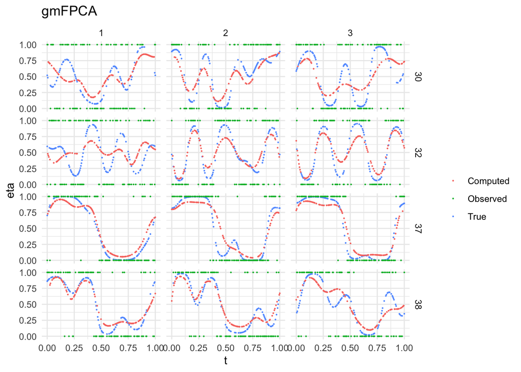

```r
# unique(comp_list_allM_ref[[1]]$id)
comp_list_allM[[1]] %>%
  filter(id %in% c(30, 32, 37, 38)) %>%
  mutate_at(vars(starts_with("eta")),
            function(x)(exp(x)/(1+exp(x)))) %>%
  mutate(eta=ifelse(is.na(Yobs), NA, eta),
         eta_comp=ifelse(is.na(Yobs), eta_comp, NA)) %>%
  ggplot()+
  geom_point(aes(x=t, y=eta, col="True"), size = 0.1, na.rm = T)+
  geom_point(aes(x=t, y=eta_comp, col="Computed"), size = 0.1,
             na.rm = T)+
  geom_point(aes(x=t, y=Yobs, col = "Observed"), size = 0.1,
             na.rm = T)+
  facet_grid(rows = vars(id), cols = vars(visit))+
  labs(title = "gmFPCA", colour="")
```

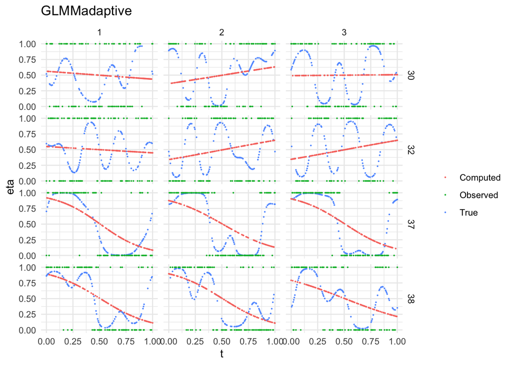

```r
comp_list_allM_ref[[1]] %>%
  filter(id %in% c(30, 32, 37, 38)) %>%
  mutate_at(vars(starts_with("eta")),
            function(x)(exp(x)/(1+exp(x)))) %>%
  mutate(eta=ifelse(is.na(Yobs), NA, eta),
         eta_comp=ifelse(is.na(Yobs), eta_comp, NA)) %>%
  ggplot()+
  geom_point(aes(x=t, y=eta, col="True"), size = 0.1, na.rm = T)+
  geom_point(aes(x=t, y=eta_comp, col="Computed"), size = 0.1,
             na.rm = T)+
  geom_point(aes(x=t, y=Yobs, col = "Observed"), size = 0.1,
             na.rm = T)+
  facet_grid(rows = vars(id), cols = vars(visit))+
  labs(title = "GLMMadaptive", colour="")
```

## Computation time

```r
# print("Computation time:")
data.frame("gmFPCA" = mean(comp_time_vec),
           "GLMMadaptive" = mean(comp_time_vec_ref, na.rm=T)) %>%
  mutate(" " = "Time (minutes)", .before=1) %>%
  kable(digits = 2) %>%
  kable_styling(full_width = F)
```

|  | gmFPCA | GLMMadaptive |
| --- | --- | --- |
| Time (minutes) | 0.39 | 0.84 |

## Integrated squared error

- Average acros all single values

```r
ise_gmfpca2 <- bind_rows(comp_list_allM, .id = "iter") %>%
  filter(is.na(Yobs)) %>%
  mutate(error = (eta_comp-eta)^2) %>%
  summarise(error = mean(error))

ise_glmmad2 <- bind_rows(comp_list_allM_ref, .id = "iter") %>%
  filter(is.na(Yobs)) %>%
  mutate(error = (eta_comp-eta)^2) %>%
  summarise(error = mean(error))
```

```r
# print("Integrated squared error:")
data.frame("gmFPCA" = ise_gmfpca2[1, 1],
           "GLMMadaptive"= ise_glmmad2[1, 1]) %>%
  kable(digits = 2) %>%
  kable_styling(full_width = F)
```

| gmFPCA | GLMMadaptive |
| --- | --- |
| 1.02 | 3.16 |

In fact the missing data scenario appears a better illustration.